# mnis_hdf5

```python
import h5py as h
import tensorflow as tf
import numpy as np
```

Cargar datos **mnist** en formato `*.npz` que contiene arreglos en archivos separados. Cada archivo contiene un solo arreglo en formato `*.npy`.

```python
DATA_URL = 'https://storage.googleapis.com/tensorflow/tf-keras-datasets/mnist.npz'
path = tf.keras.utils.get_file('mnist.npz', DATA_URL)
data = np.load(path)
```

En principio no conocemos los nombres de los arreglos (`*.npy`) guardados así que imprimimos los nombres.

```python
for k in data.keys():
    print(k)
```

```
x_test
x_train
y_train
y_test
```

Cargamos los arreglos (`numpy.ndarray`) en variables locales

```python
train_examples = data['x_train']
train_labels = data['y_train']
test_examples = data['x_test']
test_labels = data['y_test']
print(f"Forma del entrenamiento: \t instancias: {train_examples.shape} \t etiquetas: {train_labels.shape}")
print(f"Forma del prueba: \t\t instancias: {test_examples.shape} \t etiquetas: {test_labels.shape}")
```

```
Forma del entrenamiento: 	 instancias: (60000, 28, 28) 	 etiquetas: (60000,)
Forma del prueba: 		 instancias: (10000, 28, 28) 	 etiquetas: (10000,)
```

Abrimos un archivo `*.h5` (o también `*.hdf5`) en modo de escritura `'w'` y creamos *data sets* para cada uno de los arreglos bajo los grupos *train* y *test*.

```python
with h.File("mnist.h5", 'w') as file:
    file.create_dataset("train/x", data=train_examples)
    file.create_dataset("train/y", data=train_labels)
    file.create_dataset("test/x", data=test_examples)
    file.create_dataset("test/y", data=test_labels)
```

Ya que se ha creado el archivo podemos finalizar el programa. Sin embargo, ahora veremos cómo leer correctamente la información y cargarla de nuevo al programa.

Primero revisamos las clases de variables.

```python
file = h.File("mnist.h5", 'r')
group = file["train"]
train_x = file["train/x"]
x = train_x[0:1]

print(f"'file': \t {type(file)}")
print(f"'group': \t {type(group)}")
print(f"'train_x': \t {type(train_x)}")
print(f"'x': \t\t {type(x)}")
```

```
'file': 	 <class 'h5py._hl.files.File'>
'group': 	 <class 'h5py._hl.group.Group'>
'train_x': 	 <class 'h5py._hl.dataset.Dataset'>
'x': 		 <class 'numpy.ndarray'>
```

Aunque hemos cargado el arreglo en `train/x` a la variable `train_x`, realmente contiene solo la referencia a la locación en disco y no los valores del arreglo mismo. Es necesario especificar con `[first:last]` para cargar un total de `last - first` elementos en RAM.

Imprimimos los valores que contienen todas las variables y desplegamos el arreglo como imagen.

```python
print(f"File:    {file}  \t Groups: \t {file.keys()}")
print(f"Group:   {group} \t Subgroups: \t {group.keys()}")
print(f"Dataset: {train_x}")
```

```
File:    <HDF5 file "mnist.h5" (mode r)>  	 Groups: 	 <KeysViewHDF5 ['test', 'train']>
Group:   <HDF5 group "/train" (2 members)> 	 Subgroups: 	 <KeysViewHDF5 ['x', 'y']>
Dataset: <HDF5 dataset "x": shape (60000, 28, 28), type "|u1">
```

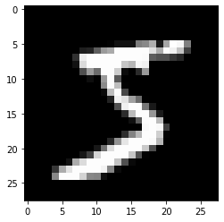

```python
import matplotlib.pyplot as plt
%matplotlib inline

plt.imshow(x.reshape(28, 28), cmap='gray');
```